# Ecosystem services

## Presentation

Ecosystem services assessments rely on a range of methods and frameworks that can be used and adapted in the case of the Hudson Bay Lowlands. We discuss the two frameworks recommended by the United Nations Convention on Biological Diversity’s (UN CBD) Global Biodiversity Framework ([UN CBD, 2022](https://www.unep.org/resources/kunming-montreal-global-biodiversity-framework)): The System of Environmental Economic Accounting (SEEA) and The Essential Ecosystem Services Variables (EEBVs); and the work done by the European Union’s assessment of ecosystems and their services.

## 1. UN CBD Global Biodiversity Framework

**SEEA framework**

The most popular and widely tested framework, the United Nation’s **System of Environmental Economic Accounting (SEEA)**, was designed to support national statistics offices include the value of ecosystems into economic reporting (SEEA, 2021). The goal of this framework is to account for the value of ecosystems in economic policy making in support of the UN Sustainable Development Goals. The UN CBD recommends that all signatory parties report on their progress towards the Global Biodiversity Framework following the guidelines of outlined in the SEEA white paper ([UN CBD, 2022](https://www.cbd.int/doc/c/0aef/09cb/0f9654d627222534df6c7a98/id-om-2022-01-inf-02-en.pdf)). This framework relies on decades of work done by experts around the world and has been tested in a wide variety of regions from Europe to Asia, Africa and South America ([Hein *et al.,* 2020](https://www.sciencedirect.com/science/article/abs/pii/S2212041620300607); [NSO India, 2021](https://seea.un.org/content/ecosystem-accounts-india-report-ncaves-project);[IBGE, 2021](https://seea.un.org/content/ecosystem-accounts-brazil-report-ncaves-project); S.A.N.B.I., in print). An increasing number of countries is adopting this framework, including the US and Canada. The SEEA framework requires the production of five “accounts” (Figure 1).

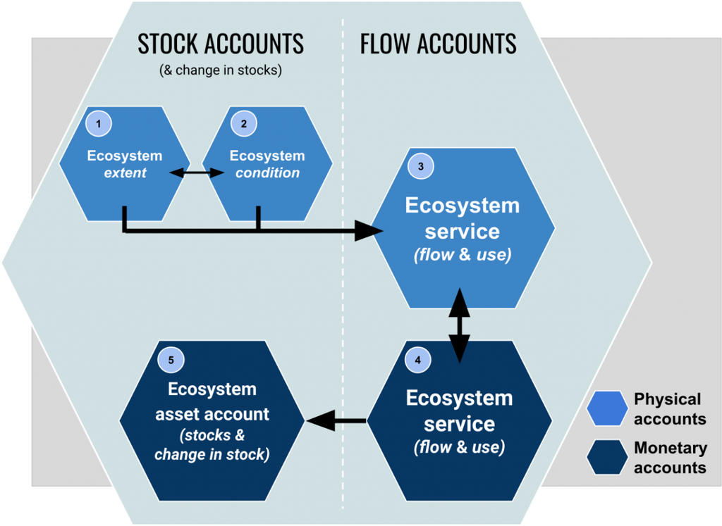

**Figure 1**. Ecosystem accounts in the UN SEEA framework and how they relate to each other. The framework requires estimating these accounts in space over a landscape to convert their ecological reality into a monetary valuation for policy. Figure from [SEEA 2021](https://seea.un.org/ecosystem-accounting).

An ecosystem extent account records the total land coverage of each type of ecosystem. A condition account then specifies in which state the ecosystem is, which is linked to its capacity to provide services. Two ecosystem services accounts (one in physical units and one in monetary terms) record the supply of services by the ecosystem and the use by people. Finally, a monetary ecosystem asset account holds the information on all the stocks of services and their change. Other thematic accounts, such as biodiversity or wetland accounts, can also be produced.

This framework provides clear guidelines on what accounts should contain, what specific terminology means and how to relate these accounts to each other. It was developed with input from a wide variety of scientific disciplines and aims to respect the ecological reality of the landscape first and then translate it into economic terms.

Methodologies on how to measure and create accounts is flexible and can be site specific, many countries have produced accounts relying on modelling tools such as the Integrated Valuation of Ecosystem Services and Tradeoffs ([InVEST; Sharp *et al.*, 2020](https://naturalcapitalproject.stanford.edu/software/invest)) or the ARtificial Intelligence for Ecosystem Services ([ARIES](https://aries.integratedmodelling.org/); [Martinez-Lopez *et al.*, 2019](https://www.sciencedirect.com/science/article/pii/S0048969718338737)). However, the SEEA framework was designed with a specific goal in mind: measuring the monetary contribution of ecosystems to societal wellbeing, and therefore may not be sufficient to include diverse priorities and ways of knowing.

**EESV framework**

The Group on Earth Observations Global Biodiversity Network (GEO BON) recently proposed the **Essential Ecosystem Services Variables (EESV)** framework ([Balvanera *et al.*, 2022](https://www.sciencedirect.com/science/article/abs/pii/S1877343522000045)) following its successful development of essential biodiversity variables, currently implemented worldwide to monitor biodiversity ([Pereira *et al.*, 2013](https://www.science.org/doi/10.1126/science.1229931)). The UN CBD also endorsed the EESV framework as means to support monitoring of ecosystem services and reporting to the Global Biodiversity Framework ([UN CBD, 2022c](https://www.cbd.int/doc/decisions/cop-15/cop-15-dec-05-en.pdf)). The EESV framework was designed to streamline and standardise the collection of data on ecosystem services. It proposes to focus on six classes of data to collect for any ecosystem service of interest (**Figure 2**).

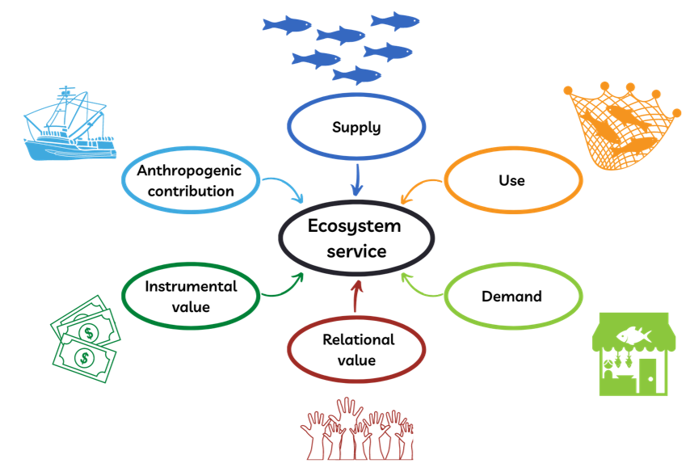

**Figure 2**. Illustration of the Essential Ecosystem Services Variables framework. All six classes are highlighted in a distinct colour and exemplified with icons relevant to a fishery as an example of an ecosystem service. The abundance of fish is a measure of supply. The catch is a measure of use. The consumption of fish by people is a measure of demand. The cultural significance of the fishery is a measure of relational value. The monetary value of fish sales is a measure of instrumental value. The size of the fishing fleet is a measure of anthropogenic contribution. Monitoring these variables together makes understanding the changing state of an ecosystem service possible.

These six classes aim to holistically capture the complexity of an ecosystem service and understand how it may be changing in several dimensions. They also make reporting on the changing state of an ecosystem service feasible and policy relevant. These classes are *ecological supply*: the ecosystem structure and functions that influence its potential to deliver ecosystem services, *use*: the actualised appropriation of a service by humans, *demand*: the implicit of explicit desire for a service, *anthropogenic contribution*: the investments human make to increase *ecological supply* or *use*, *instrumental value*: the benefits obtained from a service and *relational value*: which seeks to include values held by a diverse group of stakeholders and their unique worldviews. This framework is relatively new and only one paper to date, written by our group, has attempted to implement the approach in a real system (Schwantes & Firkowski *et al.*, in review). However, it is more flexible and holistic than the SEEA and designed to be useful for any purpose, including but not limited to accounting.

## 2. European Union’s assessment of ecosystems and their services

The European Union’s Mapping and Assessment of Ecosystems and their Services (MAES) is a project aimed at assessing the ecosystems of all member states of the European Union for the EU Biodiversity Strategy 2020. Its recent completion provides baseline information on the status of European ecosystems to support policy decisions and evaluations of impact over the next decade. The work was done following a precise framework to ensure consistent reporting and methods across the continent.

This framework is framed around important policy questions and explicitly links societal needs to the environment (Figure 3; [Maes et al., 2016](https://www.sciencedirect.com/science/article/pii/S2212041615300504)). It was implemented across the continent through engagement with stakeholders working at different scales and governance levels using the international classification of ecosystem services ([Haines-Young & Potschin, 2012](https://cices.eu/content/uploads/sites/8/2012/09/CICES-V4_Final_26092012.pdf)). The assessment focused on all types of ecosystems, including marine regions. Each ecosystem type was first assessed individually (eg: forests, wetlands, marine ecosystems, …), followed by an integrative assessment to identify overlap and common policy concerns. Important policy concerns were then used to frame the assessment of pressures on ecosystems and estimate their condition.

Some key results of this assessment include the unfavourable state of legally protected areas in Europe, the risk of pressures acting in synergy to worsen their impact and an overall decline in the ability of ecosystems to provide services, including timber, crop pollination, recreation and flood protection. This assessment further highlights the gaps in knowledge and the need for increased monitoring efforts in the region.

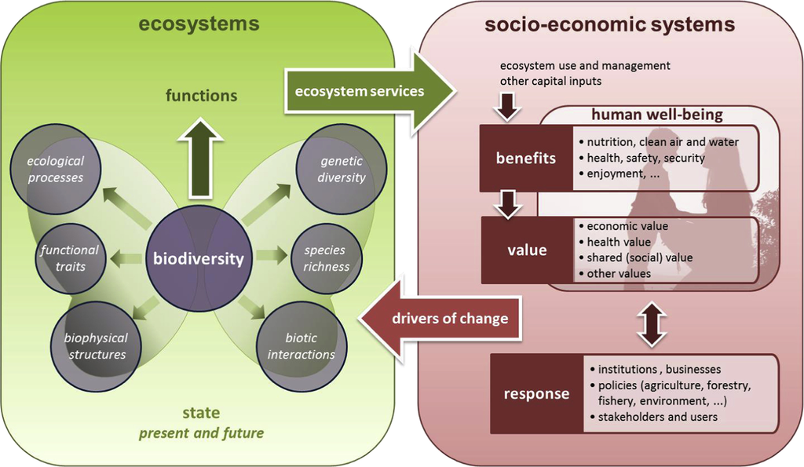

**Figure 3**. The conceptual framework for EU and national assessments of the EU Biodiversity Strategy (from [Maes *et al.*, 2016](https://www.sciencedirect.com/science/article/pii/S2212041615300504)).